# Estudios de Informática, Multimedia y Telecomunicaciones

# Tipología y ciclo de vida de los datos: Práctica 2 - Pre-Post Procesado de datos

Alejandro Guijarro - Sergio Roque Duarte Pérez

06/06/2020

# 1 Introducción y Contexto

El presente documento recoge las respuestas a los puntos recogidos en la Práctica 2 de la asignatura Tipología y Ciclo de Vida de los Datos. El informe se ha elaborado siguiendo la estructura propuesta en el enunciado de la práctica.

Se ha optado en esta segunda práctica por continuar con el tema desarrollado en la Práctica 1 de la asignatura, centrada en la extracción de datos relacionados con el virus COVID-19. Se toma para ello como punto de partida la estructura para extracción de datos generada en la Práctica 1.

Los entornos web seleccionados para la extracción de los datos citados son:

• https://www.worldometers.info/coronavirus/: estadísticas de individuos infectados.

• https://www.ree.es/es: datos de consumo eléctrico (proporcionados por Red Eléctrica) en España.

• https://covid19.isciii.es/: estadísticos sobre la evolución de los casos de COVID-19 por CCAA.

El objetivo de dicho estudio es el de evaluar el impacto de la propagación del virus COVID-19 en el consumo energético. Se plantea dicho estudio a partir del análisis de los datos disponibles de propagación y afectados por el virus, junto con los registros de consumo energético en España.

## 1.1 Descripción del Dataset

Se muestra a continuación una breve descripción de los dataset obtenidos en la Práctica 1, utilizados en esta segunda práctica para el desarrollo de la misma.

### 1.1.1 Consumo_elect_COVID_2020 & Consumo elect_COVID_2019

Registro con los datos de consumo energético en España para los meses de enero, febrero, marzo, abril, en años 2019 y 2020.

**Ev_demanda2020:**dataset incluyendo datos de demanda eléctrica diaria entre meses de enero-febrero-marzo-abril 2020. Datos exportados en fichero .csv *Consumo_elect_COVID_2020.csv*.

**Ev_demanda2019:**dataset incluyendo datos de demanda eléctrica diaria entre meses de enero-febrero-marzo-abril 2019. Datos exportados en fichero .csv *Consumo_elect_COVID_2019.csv*.

Generación de ambos dataset mediante la ejecución del script *API - Red Electrica.py*.

Importamos los datasets.

```r
elect_2020<-read.csv2("Consumo_elect_COVID_2020.csv",header=T,stringsAsFactors=FALSE, fileEncoding="latin1",sep=",",dec=".")
elect_2019<-read.csv2("Consumo_elect_COVID_2019.csv",header=T,stringsAsFactors=FALSE, fileEncoding="latin1",sep=",",dec=".")
```

### 1.1.2 Casos_COVID_ESPAÑA

Registro de datos de coronavirus en España y agrupados por CCAA (CCAA), fecha de los registros (FECHA), número de casos totales (CASOS), número de test positivos para los anticuerpos (TestAc+), número de personas hospitalizadas (Hospitalizados), personas ingresadas en UCI (UCI), número de fallecidos (Fallecidos) y número de recuperados (Recuperados).

Los datos son exportados al fichero *Casos_COVID_ESPAÑA.csv* tras la descarga de la web del ministerio de sanidad https://cnecovid.isciii.es/covid19/#documentaci%C3%B3n-y-datos. Recordamos la imposibilidad de obtener estos datos por errores sin solución de la práctica anterior y que no se pueden obtener de otra forma.

Importamos el dataset.

```r
covid_espana<-read.csv("Casos_COVID_ESPAÑA.csv",header=T,sep=",", stringsAsFactors=FALSE)
attach(covid_espana)
```

### 1.1.3 Análisis preliminar de los datasets

Una vez que hemos importado todos los dataset de la API y los caso de COVID-19, haremos uso de algunas funciones regulares de R para obtener una primera aproximación a la estructura de los datos de cada uno de los conjuntos.

- Ev_demanda2020 y Ev_demanda2019: para estos dos datasets haremos uso de las funciones “summary()” y “str()”

```r
str(elect_2019)
```

```
## 'data.frame':    120 obs. of  6 variables:
##  $ X         : int  0 1 2 3 4 5 6 7 8 9 ...
##  $ ev_demanda: num  547404 701785 746345 754085 681461 ...
##  $ date      : chr  "2019-01-01T00:00:00.000+01:00" "2019-01-02T00:00:00.000+01:00" "2019-01-03T00:00:00.000+01:00" "2019-01-04T00:00:00.000+01:00" ...
##  $ year      : int  2019 2019 2019 2019 2019 2019 2019 2019 2019 2019 ...
##  $ month     : int  1 1 1 1 1 1 1 1 1 1 ...
##  $ day       : int  1 2 3 4 5 6 7 8 9 10 ...
```

El uso de “str()” permite un primer contacto con la estructura del set, observamos en este caso como las variables son de tipo int, num y str.

```r
summary(elect_2020)
```

```
##        X         ev_demanda         date                year
##  Min.   :  0   Min.   :473815   Length:121         Min.   :2020
##  1st Qu.: 30   1st Qu.:573266   Class :character   1st Qu.:2020
##  Median : 60   Median :647239   Mode  :character   Median :2020
##  Mean   : 60   Mean   :646880                      Mean   :2020
##  3rd Qu.: 90   3rd Qu.:716400                      3rd Qu.:2020
##  Max.   :120   Max.   :819234                      Max.   :2020
##      month            day
##  Min.   :1.000   Min.   : 1.00
##  1st Qu.:1.000   1st Qu.: 8.00
##  Median :3.000   Median :16.00
##  Mean   :2.496   Mean   :15.64
##  3rd Qu.:3.000   3rd Qu.:23.00
##  Max.   :4.000   Max.   :31.00
```

El comando “summary()” muestra un análisis de los estadisticos básicos del set que resulta de gran ayuda antes de continuar con los siguientes pasos de pre-postprocesado del dataframe.

- COVID-19: para el caso de este dataset haremos uso de las funciones “head()” y “tail()”

```r
head(covid_espana)
```

```
##   CCAA     FECHA CASOS PCR. TestAc. Hospitalizados UCI Fallecidos Recuperados
## 1   AN 20/2/2020     0    0      NA             NA  NA         NA          NA
## 2   AR 20/2/2020    NA    0      NA             NA  NA         NA          NA
## 3   AS 20/2/2020    NA    0      NA             NA  NA         NA          NA
## 4   IB 20/2/2020    NA    1      NA             NA  NA         NA          NA
## 5   CN 20/2/2020    NA    1      NA             NA  NA         NA          NA
## 6   CB 20/2/2020    NA    0      NA             NA  NA         NA          NA
```

```r
tail(covid_espana)
```

```
##      CCAA     FECHA CASOS  PCR. TestAc. Hospitalizados  UCI Fallecidos
## 1667   MD 17/5/2020    NA 66302    5293          42283 3594       8863
## 1668   ML 17/5/2020    NA   121      13             44    3          2
## 1669   MC 17/5/2020    NA  1556    1039            678  112        145
## 1670   NC 17/5/2020    NA  5178    3157           2045  136        503
## 1671   PV 17/5/2020    NA 13422    5358           7016  578       1466
## 1672   RI 17/5/2020    NA  4024    1393           1496   91        351
##      Recuperados
## 1667       40736
## 1668         125
## 1669        2180
## 1670        3905
## 1671       16160
## 1672        3107
```

Como era de esperar (ya que los datos en este DataFrame están dispuestos de manera acumulativa), vemos que los primeros registros de este dataset presentan numerosos valores NaN y valores = 0. En cuanto a la cola, observamos la presencia de los registros con los valores más altos de PCRs y demás variables para cada CCAA.

# 2 Integración y Selección de los datos de interés a analizar

## 2.1 Datos consumo energético

Extraídos a partir de la aplicación API disponible en la plataforma REData de Red Eléctrica: https://www.ree.es/es.

El conjunto de datos seleccionado mediante la request lanzada a la API se ha limitado a la evolución de la demanda para los meses de enero-febrero-marzo-abril en años 2019 y 2020.

```r
r = requests.get(https://apidatos.ree.es/es/datos/demanda/
*indicamos los datos, en este caso evolución de demanda*
  **evolucion?**
*rango temporal para el que solicitamos los datos*
  **start_date=2020-01-01T00:00&end_date=2020-0325T22:00**&
*fracción temporal en la que queremos visualizar los datos (diario)*
  **time_trunc=day**&
*Zona geográfica sobre la que aplicaremos la extracción de datos.*
  **geo_limit=peninsular**&
  **geo_ids=8741**)
```

## 2.2 Evolución COVID-19 en España

En cuanto a la evolución de los datos sobre los casos del COVID-19 por comunidades autónomas, obtenemos un dataset de la web https://cnecovid.isciii.es/ mediante descarga directa. El archivo contiene los datos acumulados de la evolución de los casos para las variables descritas en el apartado anterior. Estos se encuentran ordenados por comunidad autónoma y los registros parten desde el 20 de febrero de 2020 hasta el 17 de mayo del 2020 (actualidad).

# 3 Limpieza de los datos

## 3.1 Ceros Elementos Vacíos

Se plantea en este apartado el tratamiento de los “ceros” o “elementos vacíos” mediante un barrido de los dataframes, con el fin de identificar y posteriormente tratar dichos elementos. El objetivo último es evitar que estos registros repercutan negativamente en la interpretación y conclusiones que se extraigan a partir de estos datos.

**Dataframes: elect2020 & elect 2019**

```r
NA_Noff_elect2020 <-sapply(elect_2020, function(y) sum(length(which(is.na(y))))) #count de campos NA para cada variable en el dataframe
NA_Noff_elect2020 <- data.frame(NA_Noff_elect2020) #generamos un dataframe para la visualización del total de NA "valores perdidos" por variable
NA_Noff_elect2019 <-sapply(elect_2019, function(y) sum(length(which(is.na(y))))) #count de campos NA para cada variable en el dataframe
NA_Noff_elect2019 <- data.frame(NA_Noff_elect2019) #generamos un dataframe para la visualización del total de NA "valores perdidos" por variable
```

Se presenta a continuación el resultado del preprocesado de los dataframes para identificación de elementos vacíos.

```r
NA_Noff_elect2020
```

```
##            NA_Noff_elect2020
## X                          0
## ev_demanda                 0
## date                       0
## year                       0
## month                      0
## day                        0
```

```r
NA_Noff_elect2019
```

```
##            NA_Noff_elect2019
## X                          0
## ev_demanda                 0
## date                       0
## year                       0
## month                      0
## day                        0
```

Vemos como estos dos dataframes no contienen en ningún caso elementos vacíos, la extracción de la información del entorno web para ambos dataframes se ha llevado a cabo sin NA´s resultantes.

**Dataframes: covid_espana**

Procedemos a continuación a revisar el dataframe que contiene los casos de COVID-19. Se propone para ello una metodología ligeramente diferente a la mostrada para los datos de demanda eléctrica.

Primero lo que haremos es comprobar la presencia de valores vacios mediante el uso de la función “summary()” de las expresiones regulares de R, así como el uso de “str()” que nos dará información sobre que tipo de variables se encuentra en este set.

```r
summary(covid_espana)
```

```
##      CCAA              FECHA               CASOS           PCR.
##  Length:1672        Length:1672        Min.   :0      Min.   :    0
##  Class :character   Class :character   1st Qu.:0      1st Qu.:   62
##  Mode  :character   Mode  :character   Median :0      Median : 1636
##                                        Mean   :0      Mean   : 6116
##                                        3rd Qu.:0      3rd Qu.: 5462
##                                        Max.   :0      Max.   :66302
##                                        NA's   :1671
##     TestAc.       Hospitalizados       UCI           Fallecidos
##  Min.   :   0.0   Min.   :    0   Min.   :   0.0   Min.   :   0.0
##  1st Qu.: 110.8   1st Qu.:  240   1st Qu.:  25.0   1st Qu.:  15.0
##  Median : 838.5   Median : 1134   Median : 118.0   Median : 188.0
##  Mean   :1422.8   Mean   : 3627   Mean   : 348.3   Mean   : 787.6
##  3rd Qu.:1830.0   3rd Qu.: 3808   3rd Qu.: 359.2   3rd Qu.: 739.0
##  Max.   :8366.0   Max.   :42283   Max.   :3594.0   Max.   :8863.0
##  NA's   :1036     NA's   :340     NA's   :306      NA's   :323
##   Recuperados
##  Min.   :    0.00
##  1st Qu.:   36.75
##  Median :  799.00
##  Mean   : 3342.34
##  3rd Qu.: 2870.25
##  Max.   :40736.00
##  NA's   :328
```

```r
str(covid_espana)
```

```
## 'data.frame':    1672 obs. of  9 variables:
##  $ CCAA          : chr  "AN" "AR" "AS" "IB" ...
##  $ FECHA         : chr  "20/2/2020" "20/2/2020" "20/2/2020" "20/2/2020" ...
##  $ CASOS         : int  0 NA NA NA NA NA NA NA NA NA ...
##  $ PCR.          : int  0 0 0 1 1 0 0 0 0 0 ...
##  $ TestAc.       : int  NA NA NA NA NA NA NA NA NA NA ...
##  $ Hospitalizados: int  NA NA NA NA NA NA NA NA NA NA ...
##  $ UCI           : int  NA NA NA NA NA NA NA NA NA NA ...
##  $ Fallecidos    : int  NA NA NA NA NA NA NA NA NA NA ...
##  $ Recuperados   : int  NA NA NA NA NA NA NA NA NA NA ...
```

Vemos como el set de datos acumulados presenta al inicio un gran número de registros de tipo NaN, debido a que al inicio del proceso de registro de datos no existían aún casos positivos de COVID-19 en muchas de las CCAA de España. Con el avance del proceso de recogida de datos, y el incremento de casos en el acumulado, observamos como estos valores perdidos desaparecen en el dataframe, limitando la presencia de NaN´s en las variables de tipo int.

Esta estructura resulta lógica y consistente con la naturaleza del set, datos dispuestos de forma acumulativa con unos primeros registros que resultarán nulos o bajos e irán incrementando a medida se avance en el proceso de regocida de datos.

En base a lo expuesto, asumiremos que la sustitución de los mismos por ceros no supondrá error alguno en los análisis ni las representaciones gráficas posteriores.

Antes de sustituir los valores NAN´s, haremos una selección de las variables que realmente vamos a utilizar en el análisis.

```r
if(!require(dplyr)){
    install.packages('dplyr', repos='http://cran.us.r-project.org')
    library(dplyr)
}
```

```r
# Llamada a la librería necesaria para seleccionar columnas
library(dplyr)
# Filtraremos el DataFrame para evaluar solo las variables que nos interesan
covid_espana <- select(covid_espana,CCAA,FECHA, PCR.)
```

Volvemos a comprobar los valores perdidos:

```r
summary(covid_espana)
```

```
##      CCAA              FECHA                PCR.
##  Length:1672        Length:1672        Min.   :    0
##  Class :character   Class :character   1st Qu.:   62
##  Mode  :character   Mode  :character   Median : 1636
##                                        Mean   : 6116
##                                        3rd Qu.: 5462
##                                        Max.   :66302
```

Procedemos con la sustitución de NANs por ceros.

```r
# Sustitución de valores NaN por ceros
covid_espana$PCR.[is.na(covid_espana$PCR.)] <- 0
```

Una vez hecho esto comprobaremos por última vez que ahora este dataset no presenta valores NAN:

```r
summary(covid_espana)
```

```
##      CCAA              FECHA                PCR.
##  Length:1672        Length:1672        Min.   :    0
##  Class :character   Class :character   1st Qu.:   62
##  Mode  :character   Mode  :character   Median : 1636
##                                        Mean   : 6116
##                                        3rd Qu.: 5462
##                                        Max.   :66302
```

## 3.2 Identificación y tratamiento de valores extremos

Para la identificación de valores extremos en los dataframes objeto del análisis, procedemos a la presentación de los datos mediante un diagrama de cajas para la variable en cuestión.

**elect_2019**

```
## numeric(0)
```

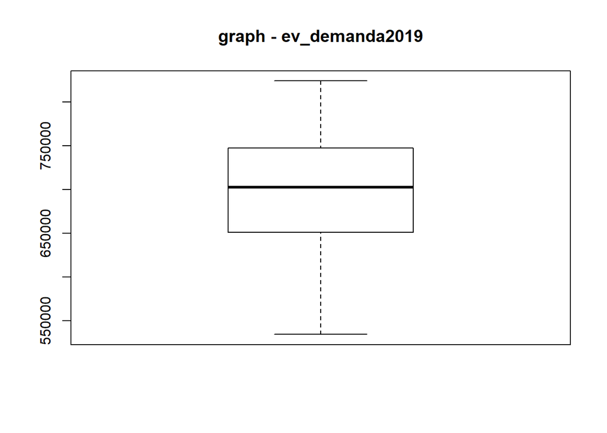

```r
boxplot.stats(elect_2019$ev_demanda)$out
```

**elect_2020**

```
## numeric(0)
```

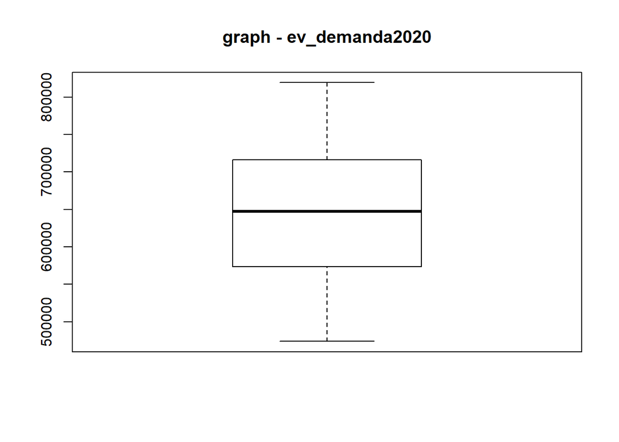

```r
boxplot.stats(elect_2020$ev_demanda)$out
```

**Casos_COVID_ESPAÑA**

```
##   [1] 15722 17397 18900 21569 24473 27420 30794 14263 33160 15025 34186 16104
##  [13] 35058 18520 37604 19991 39404 21804 41191 23460 43027 24734 44768 26032
##  [25] 45660 26824 46186 28323 47749 29647 49139 31043 50556 31824 51505 32984
##  [37] 52367 13698 34027 52909 14054 34726 53250 14329 35197 54241 14680 13697
##  [49] 36505 55343 15151 14380 37354 56245 15997 14903 38316 57084 16349 15293
##  [61] 39943 57899 14588 14644 40448 58384 14725 14781 41676 58591 14936 14951
##  [73] 43112 59210 15053 15141 43802 59847 15128 15510 44892 60528 15365 15692
##  [85] 45544 60961 15509 15990 46261 61472 15609 16222 46811 61705 15664 16404
##  [97] 47755 61835 15706 16589 48158 62426 15785 16690 48654 62912 15832 16885
## [109] 48916 63259 15910 16993 49307 63545 15967 17165 49850 63682 16017 17283
## [121] 50234 63799 16050 17334 50366 63911 16080 17429 50771 64235 16144 17520
## [133] 50924 64560 16184 17625 51190 64835 16237 17716 51733 65064 16278 17822
## [145] 51935 65280 16343 17952 52162 65363 16387 17995 54807 65415 16431 18048
## [157] 55144 65605 16453 18105 55287 65817 16470 18173 55313 66006 16513 18272
## [169] 55562 66187 16587 18369 55685 66279 16618 18470 55836 66297 16648 18512
## [181] 55921 66302
```

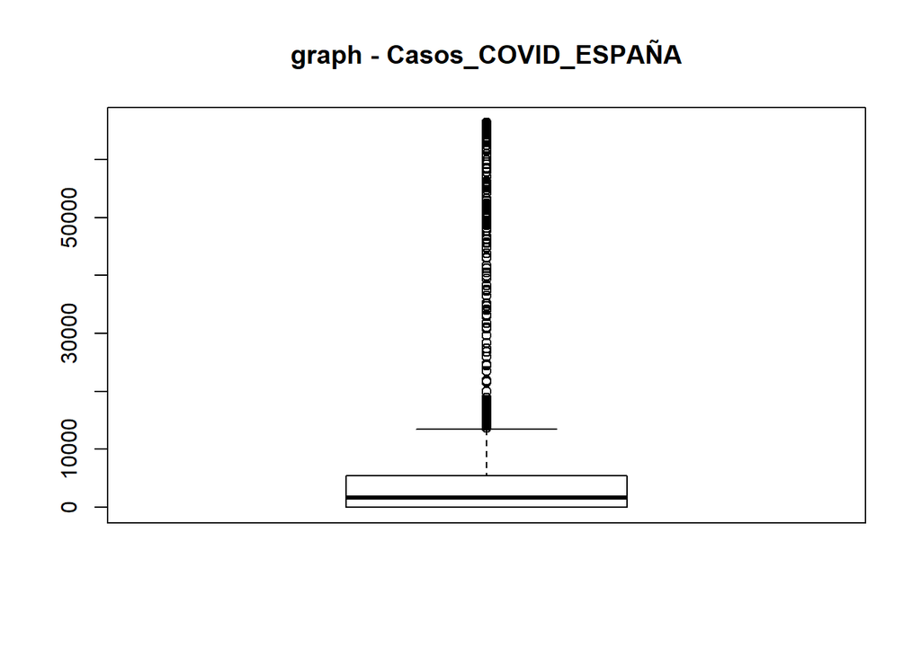

```r
boxplot.stats(covid_espana$PCR.)$out
```

Como se aprecia en el Boxplot de los casos acumulados del COVID por comunidades autónomas, existe una gran cantidad de valores extremos. Volviendo a la naturaleza del dataframe, esto resulta de nuevo lógico, consecuencia del gran volumen de datos nulos en los primeros registros el Dataframe. Al tratarse de datos acumulativos, estos valores extremos no se deberán eliminar, resultanto necesarios para el adecuado postproceso de los datos.